# MA615 MidTerm Project

10/18/2019

## Introduction

The data we acquired was the Reef Life Survey, Carried out by the professional divers to study the coral reef lives and to improve the biodiversity. Reef Life Survey(RLS) motivated professional divers to gather the data from observations of coral reefs. RLS aimed to raised the global awareness to marine biodiversity and is freely available to all users.

## Data and Material

I download the data from the RLS portal http://reeflifesurvey.imas.utas.edu.au/static/landing.html to find a dataset for this study. I chose the cryptic fish data from 2006 to 2019 and study the reef habitat.

Before we carry out any further study on the data, we should clean the data first.

## Data Cleaning

We would delete the lines with N/A entries.

Luckily, we do not have any missing entries in any rows because te survey was carefully carried out. We get to keep all the original data from the dataset we acquired.

Since there are 68459 observaations in the data and 50073 of them are in Australia, 73.14% of all the observations, we decided to study the data specifically in Australia.

Among the 50073 observations in Australia, 48736 of them belong to the Actinopterygii Class. In order to carry out a more precise study, we choose to study the Actinopterygii as the majority.

## Data Separating and Grouping

We noticed that the column of SurveyDate was entries of a form as year-month-day-time. Hence we separate the columns into the 4 columns and factor them.

I grouped the data or 4 different aspects, the Year, Family, Taxon and Depth, which are, in my opinion, the 4 aspects that would be representative in relation to the total count of blocks of reefs.

## Draw the plots for each aspect.

#### Plots for data grouped by years

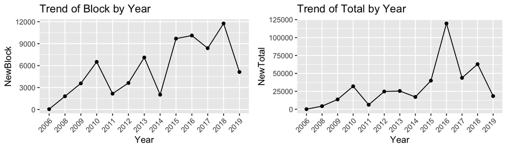

As we could see in the plots, the trend of blocks observed from 2006 to 2019 has been climbing up and down. It has its first drop in 2011, same as the first drop of total number observed. Then they both have a drop in the year 2014. This could be the result of climate changing or environment problems happened in these 2 years. The first plot has its climax point in the year 2018 and the total number trend has its climax point in 2016.

## Plots for data grouped by Families

[figure not shown]

## 10 Families habitats at lowest Depth

[figure not shown]

[figure not shown]

## 10 Families habitats at highest Depth

[figure not shown]

[figure not shown]

## 20 Taxons habitats at lowest Depth

[figure not shown]

[figure not shown]

## 20 Taxons habitats at highest Depth

[figure not shown]

[figure not shown]

## Plots for data ordered by Depths

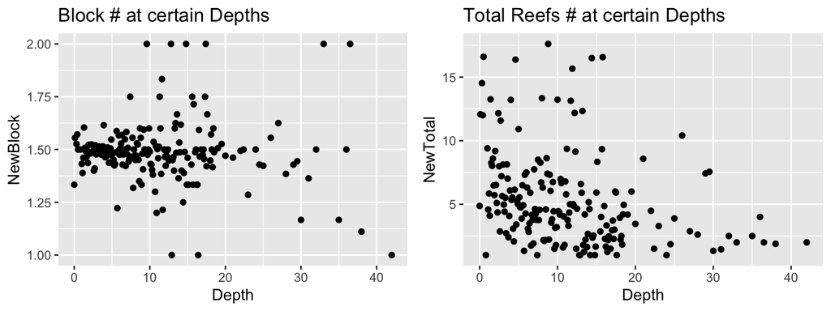

Regardless of the family and taxon, most of the observations of blocks and total are under depth 20.

## Reference

Reef Life Survey Data Portal: http://reeflifesurvey.imas.utas.edu.au/static/landing.html